# Intro to Python - Pre Course Materials

Material Updated: August 2021 | Need help? Contact the team.

# 1 Intro to Python

This is an introductory level course aimed to introduce the programming language, Python. This course will cover basic concepts and give you the confidence to work independently within Python.

No prior coding or statistical knowledge is assumed.

The course is split into modules; each module will build upon the previous one.

# 2 Course Materials

The **zipped** course materials can be found on the Learning Hub under the header “Course Material”. Please click the “download folder” button.

Chrome: This should save the .zip folder to your download folder.

Internet Explorer: Choose “Save” from the yellow bar

In windows explorer (or equivalent) fin the .zip folder.

Right click on the folder and choose extract all.

Change the destination folder to be the folder to your default working directory - this is probably C/Users/Your_Username.

If you are unsure of your working directory instructions can be found later in this notebook under “Checking your working directory”.

The course materials are in several folders:

- course_materials - HTML Documents, PDF Documents etc to support the course.
- data - contains the data we will use during the course.
- notebooks - Contains the Jupyter Notebooks that we’ll use in the course. These are a kind of Python file.
- outputs - A location to save files.
- solutions - Contains python files (.py) used within the notebooks to give answers to the questions. These are loaded from within the Jupyter Notebook.

# 3 File Formats

This course contains documents in the following formats:

- HTML Files
- CSV Files
- Excel Files
- Jupyter Notebook Files

Some departments have issues with reading excel files in Python. If you have run the solution code and still get an error you may need to save as a different file type in excel. You will also need to contact your department for guidance about how to read excel files.

# 4 Software Requirements

- Anaconda Suite ONS Current version - ANACONDA Anaconda 2020.07 (64 bit) for Python 3.8.3 - (The version numbers may change over time - as long as Anaconda is listed this is fine.)

Some Users may also have Python Anaconda 4.4 for Python 3.6 which is also fine.

Anaconda Suite is a collection of software (including Jupyter Notebooks, Spyder and Jupyter QT console) and packages (including Pandas, Numpy, Matplotlib and Statsmodels) that are used for this course.

- Web browser

*Internet connection not necessary*

- Excel / Spreadsheet program

*Viewing .csv and .xlsx documents in the native program can be useful at times.*

## 4.1 Software / Package Versions

Contents of this course are written for specific software and package versions.

Using different versions may have slight differences in some parameters. Python and it’s packages are usually backwards compatible so if you have a newer version the course should still function as expected.

We will explore how to find your version after we load each package.

ONS currently uses:

- Anaconda 2020.07
- Python 3.8.3
- Pandas 1.0.1

This course has also been tested on version:

- Anaconda 4.4
- Python 3.6
- Pandas 0.20.1

# 5 Installing Anaconda Suite

The following advice and guidance applies to staff at the Office for National Statistics.

If you are part of another government department and using a networked laptop please approach your IT team for how to install Anaconda Suite.

If you are using a non networked laptop and have permission to do so please follow the instructions [on the anaconda website](https://www.anaconda.com/distribution/). Please choose the version starting Python 3 and the right Operating System (OS).

## 5.1 ONS Colleagues

1. From Reggie choose “Service Desk” you may need to enter your email address.
2. Choose “I want something”
3. Choose “Software, Applications and Platforms”
4. Choose “Computer Software - Add/Transfer”
5. Choose “Install”
6. In the box underneath “Please select the Desktop/Laptop software you need to be Installed/Removed/Transferred” type “ANACONDA Anaconda 2020.07 (64 bit) for Python 3.8.3” and click to select. n.b (The version numbers may change over time - as long as Anaconda is listed this is fine.)
7. Add your asset number (on a sticker on your device)
8. Does this software need to be installed on/removed from multiple PCs? - Choose No
9. Choose Order Now.

During busy times it may take a few days for software to be installed. Please plan accordingly if you are on a course; online alternatives (RStudio cloud) are available if you cannot get software installed in time.

# 6 Opening Jupyter Notebooks

This step may vary depending on your operating system.

From the start menu choose

All Programs `->` Anaconda 3 (64bit) `->` Jupyter Notebooks.

Jupyter Notebook will open in your default internet browser - usually Internet Explorer

# 7 Jupyter Notebook Dashboard

First launched when you open Jupyter Notebooks; this is the area where you will create or open new Notebooks.

The files and folders that are stored here are the exact same as your current working directory (for me that’s `C:/users/hodgeh`)

This is why we request you save the course materials to this folder.

# 8 Checking your working directory

To check your working directory you will need to open a new Jupyter notebook.

To do this click “New” on the right-hand side of the screen and choose “Python 3”

[figure not shown]

*Creating a blank notebook*

This will open a new blank notebook.

In this notebook will be a box surrounded with a border - this is a cell.

In the cell type

`%pwd` - n.b some versions will accept a space between the % and pwd - some will not.

and press `CTRL` and `ENTER`

Below the cell an output will appear - this is your current working directory.

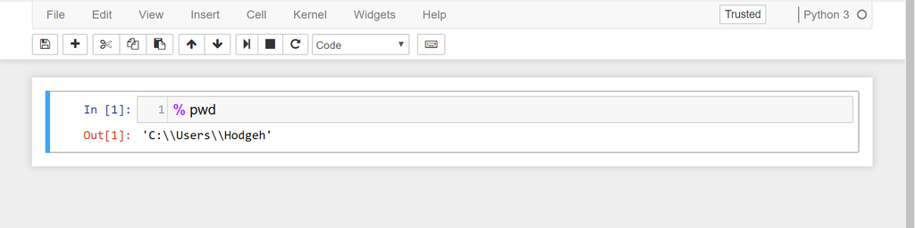

*Finding the working directory*

This is the location you will need to save the course materials to.

## 8.1 Opening the course materials

Now you have saved the course documents in your current working directory you should be able to see a folder called “Intro to Python” in the home tab of Jupyter Notebooks.

[figure not shown]

*Selecting the Intro to Python Folder*

- Click on folder name “Intro to Python”
- Choose Notebooks
- Choose “chapter 1”
- chapter 1 will now load in a new tab.